# Size distributions for fish and fish

Nick Toimieri

# 1 FUNCTIONS

# 2 fish

## 2.1 Import and manipulate data

For data processing:

NOTE: Transects with visibility < 2 m were deleted from the analysis.

NOTE: These analyses include 2015.

NOTES

- Some rockfishes were recorded in the ‘adult’ category (eg SECA instead of SECAy) but were small.
- Set minimum size for rockfishes to 10 cm. fish <= to 10 cm were classified as YOY.
- Maintained their original designation in SPECIES column. New designation in the ‘group’ column.

Because there were a lot of zeros for some species, we lumped some species or taxa into higher taxonomic categories. Species higher grouping used in the analyses are:

```
##    Spp_Code Spp_Group            Common_Name
## 1  BAITBALL      BAIT  bait-sardines-anchovy
## 4    SEBYTy    SEBYTy   yellowtail-black yoy
## 5      SEME      SEME         black rockfish
## 8      SEMY      SEMY          blue rockfish
## 12     SCMA      SCMA                cabezon
## 14    SEPIy     SEPIy    canary rockfish YOY
## 15     SENE      SENE         china rockfish
## 17     SECA      SECA        copper rockfish
## 20     HEXA      HEXA        Hexagrammos spp
## 23     CLUP      BAIT                Herring
## 25     HEDE      HEXA         Kelp Greenling
## 26     BRFR      EMBI         Kelp Surfperch
## 29     OPEL      OPEL                Lingcod
## 34     ENMO      BAIT       Northern Anchovy
## 38     SASA      BAIT        pacific sardine
## 39     OXPI      HEXA      Painted Greenling
## 41     RHVA      EMBI             Pile perch
## 45     HEHE      HEXA         Red Irish Lord
## 47     HELA      HEXA         Rock Greenling
## 49     RYOY      RYOY           rockfish_yoy
## 55     CYAG      EMBI       Shiner Surfperch
## 60     EMLA      EMBI      Striped Surfperch
## 61     EMBI      EMBI            Surfperches
## 63     AUFL      AUFL              Tubesnout
## 66     HEST      HEXA Whitespotted greenling
## 69    SECAy     SECAy    Copper rockfish YOY
## 70    SEMEy     SEMEy     black rockfish YOY
```

## 2.2 Size distributions for select spp

The point of looking at the size distributions is to see if the observed recruitments contributed to age-structure. That is, can we see recruitment pulses in the age structure through time. For the rockfish, the only spp that really makes sense to look at is black rockfish (SEME). They had settlement early on (2016) and are reasonably abundant. We didn’t see many adult yellowtail, for example. I also included some plots of EMBI (surfperch) and HEXA (greenling), although these are spp groups not individual species.

Total counts across years by group:

```
##   group QUANTITY
## 1  AUFL      204
## 2  BAIT      348
## 3  EMBI      437
## 4  HEXA      404
## 5  OPEL       33
## 6  SCMA       21
## 7  SECA       16
## 8  SEME     1188
## 9  SENE       13
```

### 2.2.1 Black rockfish

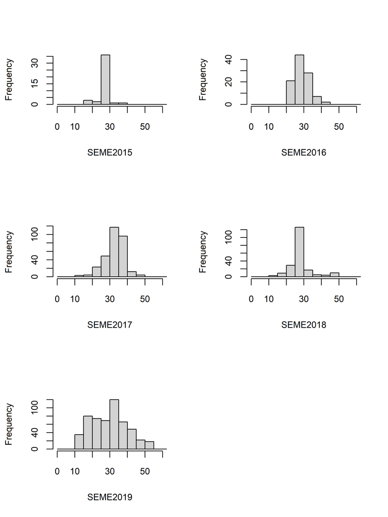

Size distribution of black rockfish across years for all sites combined.

```
## Package 'sm', version 2.2-5.6: type help(sm) for summary information
```

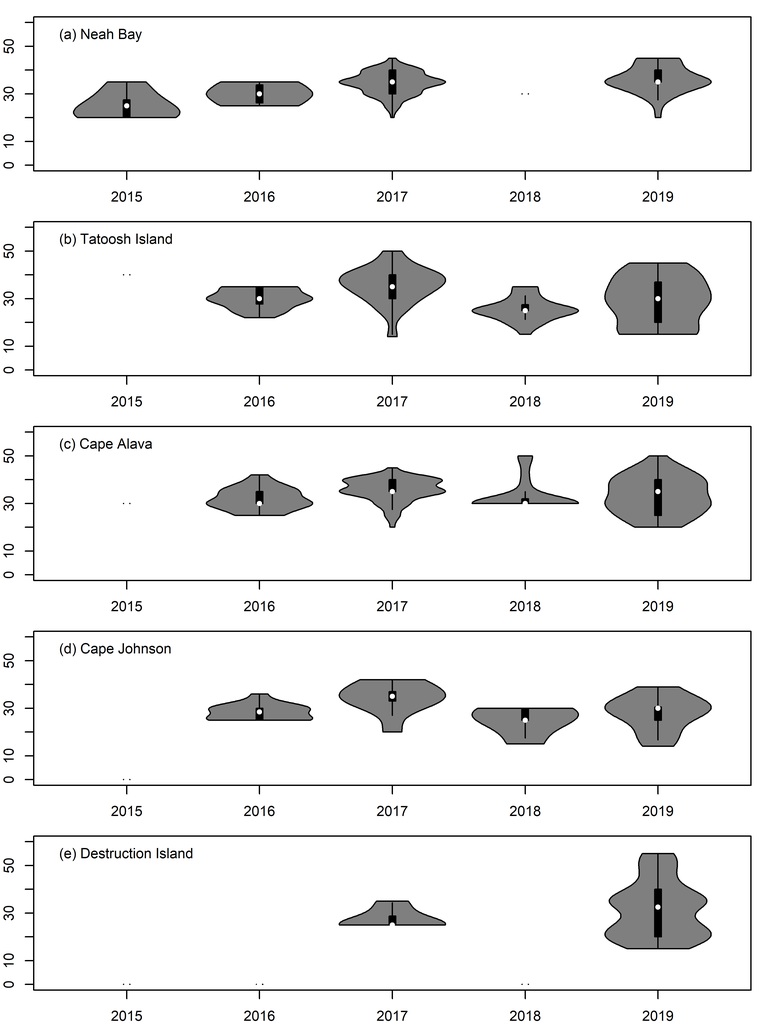

### 2.2.2 Perch

I graphed these because I could. These aren’t really separate species

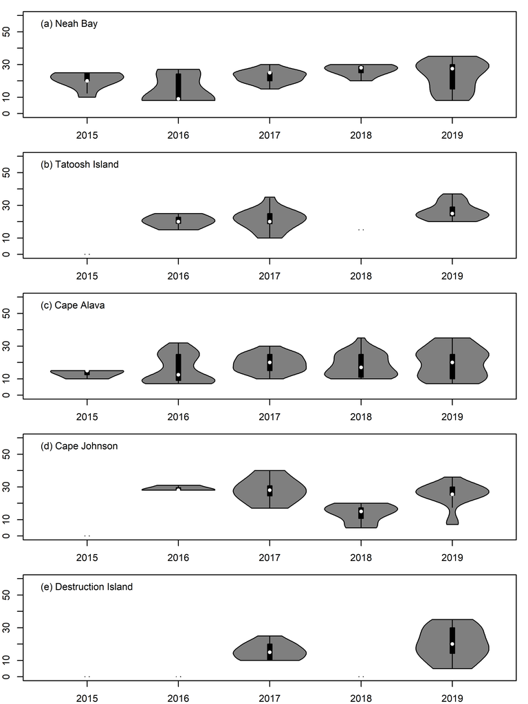

### 2.2.3 Greenling

I graphed these because I could. These aren’t really separate species.

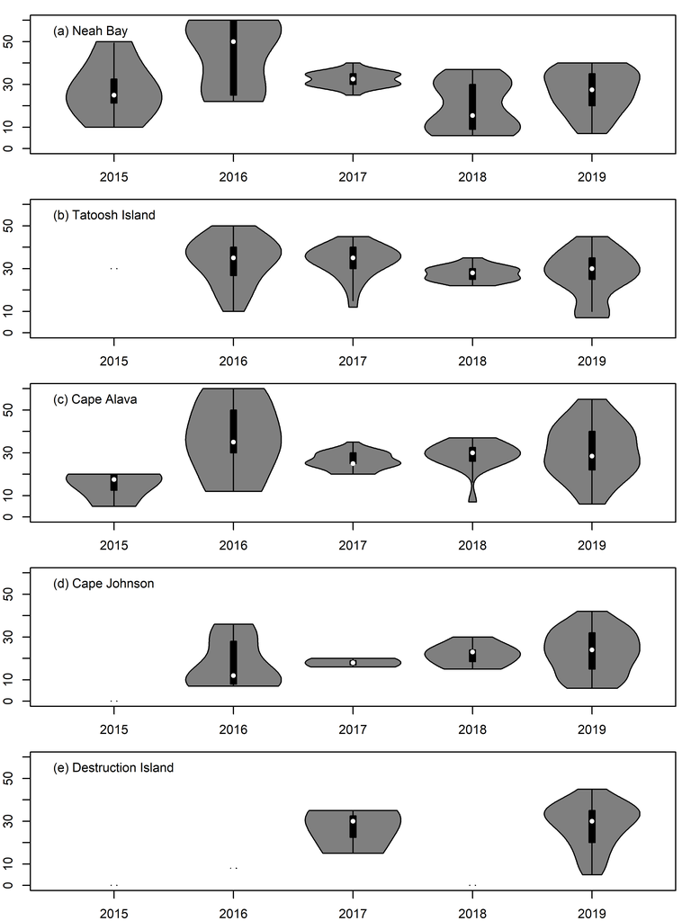

## 2.3 Urchins

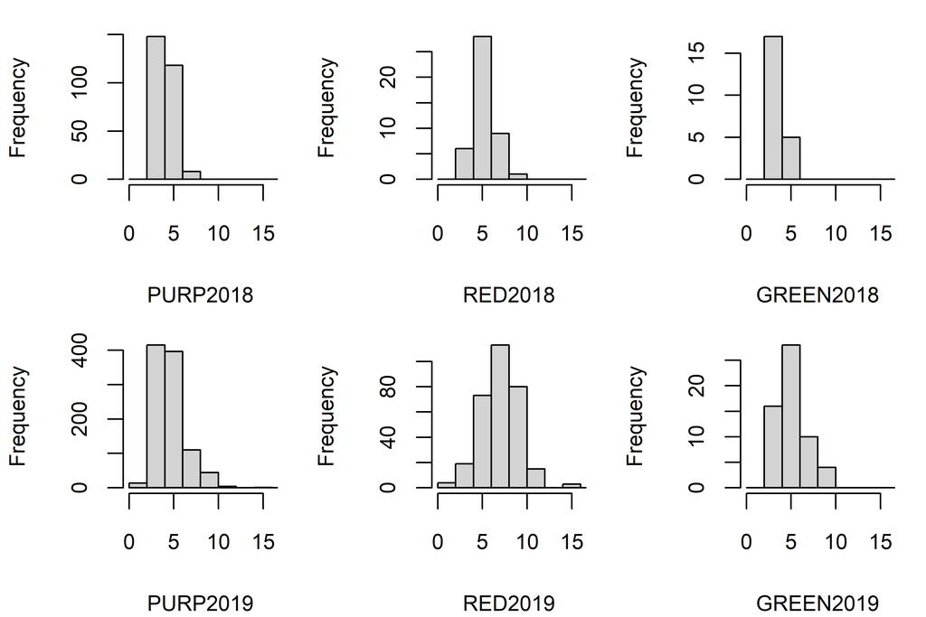

Urchin size distributions across years for all sites combined.

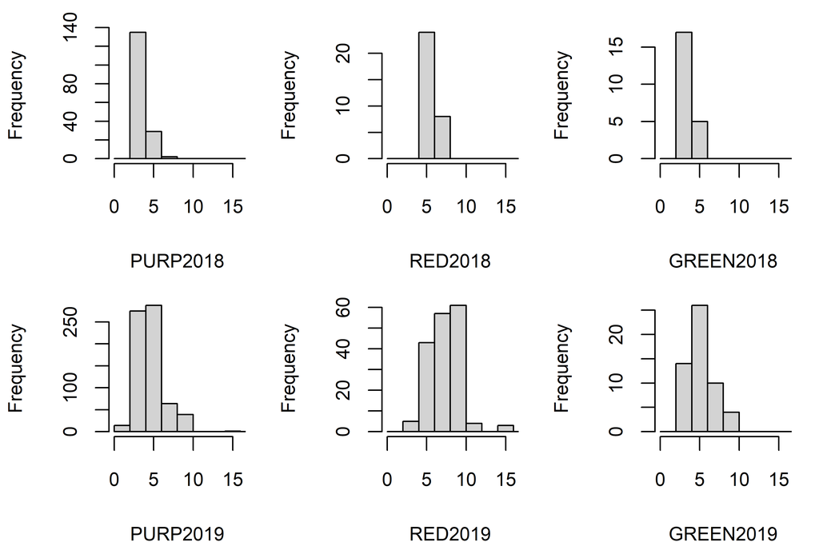

Urchin size distributions across years for at Tatoosh Island.

## 2.4 Seastars

Sum of invert densities across years.

```
##                 lump dens_weighted
## 11    large_barnacle    44.5640405
## 17   orange_cucumber    43.2803968
## 19     purple_urchin    40.0172770
## 27          tunicate    32.7546825
## 2         blood_star    29.9255339
## 14      leather_star    26.0999585
## 20        red_urchin    15.1981326
## 7       green_urchin    12.6892582
## 23 shelled_gastropod     9.6818412
## 18      P_ochraceous     5.5667544
## 12  large_nudibranch     5.0543458
## 21      sea_cucumber     3.0833333
## 3     brood_sea_star     2.7091667
## 1            bivalve     2.0591674
## 10     large_anemone     1.9567481
## 5             chiton     1.9236639
## 22      sea_star_YOY     1.1208333
## 4            Cal_cuc     1.0500000
## 25     small_anemone     0.8416667
## 6              crabs     0.8400435
## 9          kelp_crab     0.7172619
## 8       hermit_crabs     0.7125000
## 15    med_nudibranch     0.5635111
## 13    large_sea_star     0.5570169
## 16      med_sea_star     0.4000000
## 24   shelled_mollusk     0.2833333
## 26            sponge     0.2500000
```

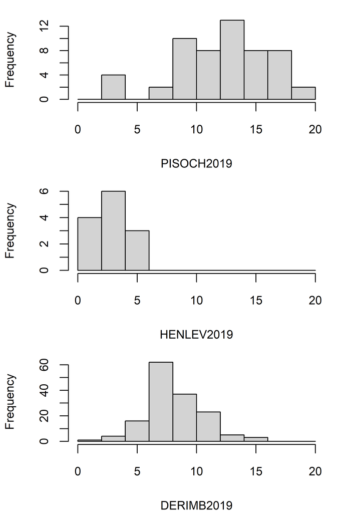

Seastar size distributions in 2019.